# Molecular Marker Assisted Plant Breeding

Single Marker Regression

Felipe Ferrão

University of Florida

**Objectives:**

- 60 minutes of hands-on
- Single Marker regression in the statistical framework
- Quantitative Genetics

**Extra information**

- [HOS 6236 – Website](https://lfelipe-ferrao.github.io/class/mas/)
- About the [author](https://lfelipe-ferrao.github.io/)
- About the [UF/IFAS Plant Breeding](https://programs.ifas.ufl.edu/plant-breeding/)

# Introduction

The simplest method for the analysis of QTL mapping data is to consider each marker individually, split the individuals into groups, according to their genotypes at the marker, and compare the groups’ phenotype averages.

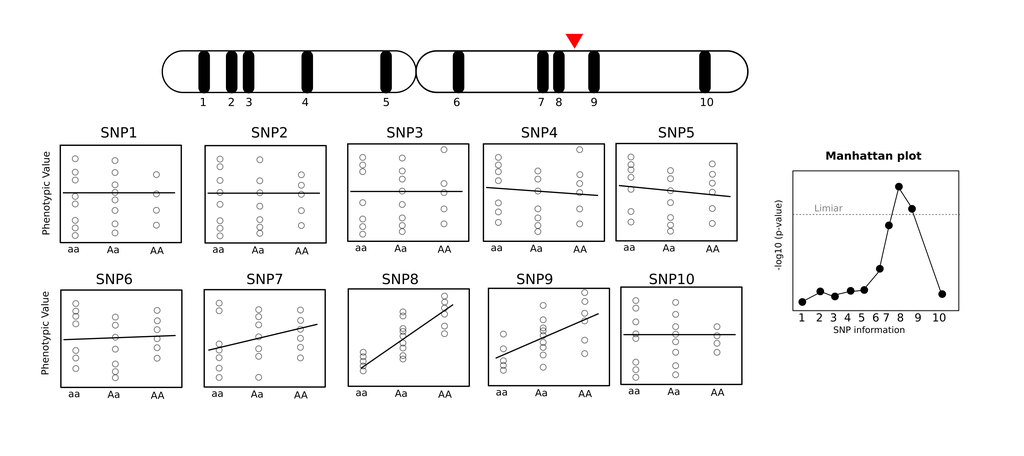

Summary on using simple regression models for QTL mapping

# Regression Models

## Simulated example

Now, we will run the `lm` function for all the simulated markers.

- What is the p-value showing us?
- Which marker is associated with my trait based on the result below?
- What is the effect of the marker ?
- What is the direction of the effect (positive or negative)?

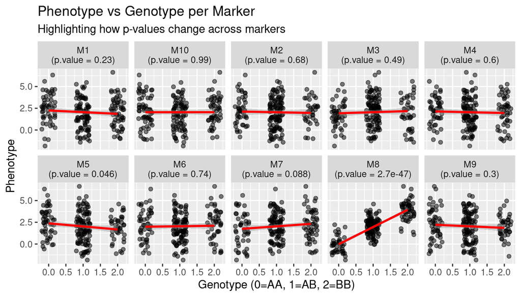

## Statistical Models

$$y_j = \mu + \beta x_j + e_j$$

- $y$ : phenotypic value for the individual j
- $\mu$ : intercept
- $x_j$ : dosage effect, in the case of backcross, for example, MM (1) and Mm (0)
- $\beta_j$: slope of the regression that will measure the marker effect
- Hypothesis: $H0: \beta =0$ vs. $H0: \neq \beta 0$

We can express the same linear regression model in **matrix notation** as:

$$\mathbf{y} = \mathbf{X}
\boldsymbol{\beta} + \boldsymbol{\varepsilon}$$

Where:

- $\mathbf{y}$ is an $n \times 1$ vector of response values
- $\mathbf{X}$ is an $n \times p$ design matrix (including a column of 1s for the intercept)
- $\boldsymbol{\beta}$ is a $p \times 1$ vector of unknown regression coefficients
- $\boldsymbol{\varepsilon}$ is an $n \times 1$ vector of random errors

To estimate $\boldsymbol{\beta}$, we minimize the **residual sum of squares (RSS)**, using the Least Squares Estimation theory, in four main steps:

- Write the RSS
- Expand the RSS expression
- Take derivative $\boldsymbol{\beta}$ and set to zero
- Solving for $\boldsymbol{\beta}$, we get the least squares estimator

$$\begin{aligned}
\mathbf{y} &= \mathbf{X} \boldsymbol{\beta} +
\boldsymbol{\varepsilon} \\\\
RSS(\boldsymbol{\beta}) &= (\mathbf{y} - \mathbf{X}
\boldsymbol{\beta})^\top (\mathbf{y} - \mathbf{X} \boldsymbol{\beta})
\\\\
&= \mathbf{y}^\top \mathbf{y} - 2 \boldsymbol{\beta}^\top
\mathbf{X}^\top \mathbf{y} + \boldsymbol{\beta}^\top \mathbf{X}^\top
\mathbf{X} \boldsymbol{\beta} \\\\
\frac{\partial RSS}{\partial \boldsymbol{\beta}} &= -2
\mathbf{X}^\top \mathbf{y} + 2 \mathbf{X}^\top \mathbf{X}
\boldsymbol{\beta} = 0 \\\\
\mathbf{X}^\top \mathbf{X} \boldsymbol{\beta} &= \mathbf{X}^\top
\mathbf{y} \\\\
\hat{\boldsymbol{\beta}} &= (\mathbf{X}^\top \mathbf{X})^{-1}
\mathbf{X}^\top \mathbf{y}
\end{aligned}$$

## Testing Hyphotesis

In QTL mapping, the importance of a genetic marker can be tested by comparing two models, using a basic idea that we want to test whether adding one or more predictors to a model significantly improves our ability to explain the response variable, by affecting the residual terms of the model. Therefore, we can define two main models:

- **Null model ($H_0$)**: the marker is not associated with the trait, and therefore the regression model only includes the intercept.
- **Alternative model ($H_A$)**: the marker is associated with the trait, and therefore we have the full model with an explicit effect for the marker effect.

This comparison is done via the **LOD score**, which is based on the ratio of the likelihoods under the two models. Assuming the residuals follow a normal distribution, the **likelihood** for the linear model:

$$\mathbf{y} = \mathbf{X} \boldsymbol{\beta} + \boldsymbol{\varepsilon},
\quad \boldsymbol{\varepsilon} \sim N(0, \sigma^2 \mathbf{I})$$

is given by:

$$L(\boldsymbol{\beta}, \sigma^2) = \prod_{i=1}^{n} \frac{1}{\sqrt{2\pi
\sigma^2}} \exp\left( -\frac{(y_i - \mathbf{x}_i^\top
\boldsymbol{\beta})^2}{2\sigma^2} \right)$$

Taking the log of the likelihood:

$$\log L = -\frac{n}{2} \log(2\pi) - \frac{n}{2} \log(\sigma^2) -
\frac{1}{2\sigma^2} \sum_{i=1}^{n} (y_i - \mathbf{x}_i^\top
\boldsymbol{\beta})^2$$

Let:

- $\text{RSS}_0$: Residual sum of squares under $H_0$
- $\text{RSS}_1$: Residual sum of squares under $H_A$

The **LOD score** is computed as:

$$\text{LOD} = \log_{10} \left( \frac{L_1}{L_0} \right)
= \frac{n}{2} \log_{10} \left( \frac{\text{RSS}_0}{\text{RSS}_1} \right)$$

**Interpretation**

- Higher LOD values indicate stronger evidence that the marker explains phenotypic variation.
- A common threshold is **LOD ≥ 3**, which roughly corresponds to a p-value of 0.001.

# Hands on

Throughout this class, we will use functions from the `r/qtl` R package, which has been widely adopted over the past decade in animal, plant, and human genetics research. If you’re interested in exploring this topic further, we highly recommend the materials developed by **Karl Broman** — a leading researcher in the field. His [website](https://rqtl.org/) includes comprehensive tutorials, books, and links to active discussion groups. Additional resources and updates can also be found on his [GitHub page](https://github.com/kbroman).

## QTL mapping in mice

- Sugiyama et al., (2002): QTL associated with blood pressure, heart rate, and heart weight in CBA/CaJ and BALB/cJ mice. Physiol Genomics 10:5–12. [Link](https://journals.physiology.org/doi/full/10.1152/physiolgenomics.00002.2002)
- Number of individuals: 163
- 93 markers
- F2 population

```r
library(qtl)
sug <-  read.cross("csv",
                  "/home/felipe/Dropbox (UFL)/classes/Molecular_Breeding/class3_QTLMapping/",
                  "QTLmapping_6.csv",
                  genotypes=c("CC", "CB",   "BB"),
                  alleles=c("C",    "B"))
```

```
##  --Read the following data:
##   163  individuals
##   93  markers
##   6  phenotypes
##  --Cross type: f2
```

```r
summary(sug)
```

```
##     F2 intercross
##
##     No. individuals:    163
##
##     No. phenotypes:     6
##     Percent phenotyped: 95.1 95.7 99.4 99.4 100 100
##
##     No. chromosomes:    19
##         Autosomes:      1 2 3 4 5 6 7 8 9 10 11 12 13 14 15 16 17 18 19
##
##     Total markers:      93
##     No. markers:        5 7 5 5 5 4 8 4 4 5 6 3 3 5 5 4 4 6 5
##     Percent genotyped:  98.3
##     Genotypes (%):      CC:23.9  CB:50.2  BB:26.0  not BB:0.0  not CC:0.0
```

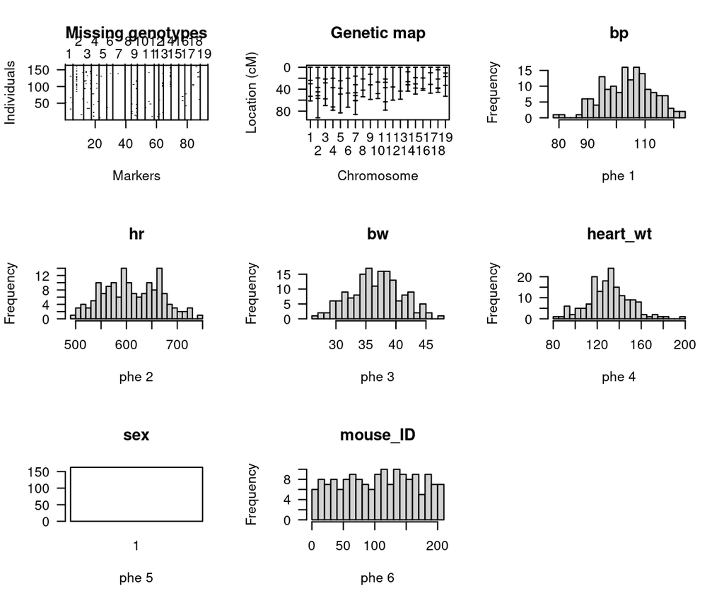

```r
plot(sug)
```

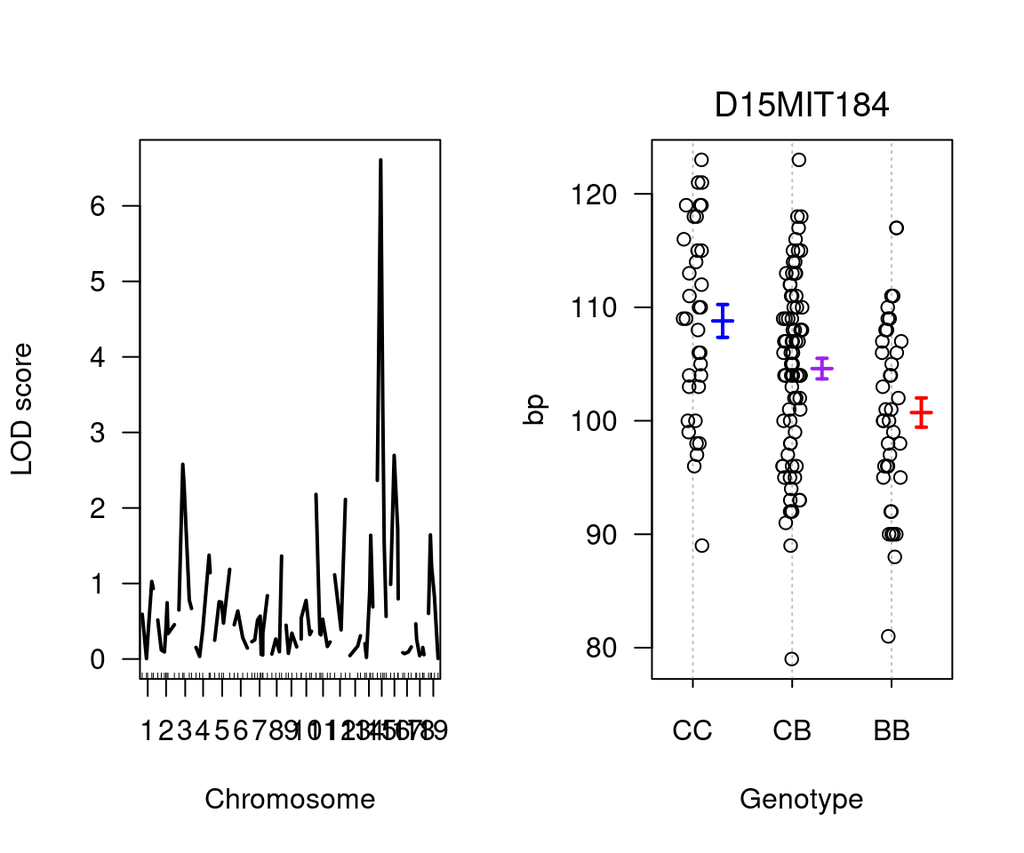

```r
# SINGLE MARKER REGRESSION  (homework)
mr <- scanone(sug, pheno.col=3,method="mr")
par(mfrow=c(1,2)) # compare the groups’ phenotype averages
plot(mr, ylab="LOD score")
plotPXG(sug, "D15MIT184")
```

```r
#plotPXG(sug, "D1MIT171")
summary(mr,threshold = 3)
```

```
##           chr  pos  lod
## D15MIT184  15 22.8 6.61
```

```r
# Estimating the importance and effects
qc <- c(15) # what chr?
qp <- c(22.8) # what position?
fake.f2 <- subset(sug, chr=qc) # subset the marker
fake.f2 <- calc.genoprob(fake.f2, step=2, err=0.001) # conditional prob

# Estimating the effects and importance
qtl <- makeqtl(fake.f2, qc, qp, what="prob")
lod <- fitqtl(fake.f2, pheno.col=1, qtl, formula=y~Q1,
              method="hk",get.ests=TRUE, dropone=FALSE)
summary(lod)
```

```
##
##      fitqtl summary
##
## Method: Haley-Knott regression
## Model:  normal phenotype
## Number of observations : 155
##
## Full model result
## ----------------------------------
## Model formula: y ~ Q1
##
##        df        SS        MS      LOD     %var Pvalue(Chi2)   Pvalue(F)
## Model   2  1224.887 612.44326 3.799576 10.67496  0.000158644 0.000187916
## Error 152 10249.501  67.43092
## Total 154 11474.387
##
##
## Estimated effects:
## -----------------
##                est       SE       t
## Intercept 104.6787   0.6607 158.445
## 15@22.8a   -4.0582   0.9523  -4.261
## 15@22.8d   -0.1627   1.3236  -0.123
```

# In light of Quantitative Genetics

Beyond the use of statistical models, single marker regression can also be interpreted through the lens of quantitative genetic theory. To explore this, we revisit some key concepts from linkage mapping and use a backcross (BC) population as a simplified example.

We begin with a few important assumptions:

- We have a marker locus M for which genotypic data are available. In a backcross population, we expect segregation at the marker locus to follow a 1:1 ratio, specifically MM:Mm.
- There is a QTL (Q) linked to the marker locus M, but the QTL itself is unobservable (i.e., we do not have direct genotypic data at the Q locus). The goal is to infer the presence and effect of the QTL through marker information, leveraging the concept of linkage disequilibrium (LD) between M and Q.

Assuming a backcross population derived from the cross MmQq×MMQQ, the expected genotypic frequencies at the marker and QTL loci depend on the recombination fraction between them.

| Geno | QQ | Qq | Freq |
| --- | --- | --- | --- |
| MM | (1-r)/2 | r/2 | 1/2 |
| Mm | r/2 | (1-r)/2 | 1/2 |
| Freq | 1/2 | 1/2 | 1 |

We want to compute the **conditional probability** of the QTL genotype, given the marker genotype. This is important because the QTL itself is unobserved, and we estimate its effect based on flanking marker genotypes. To remendir it, let’s remeber the condictional probability theory, where we have the following question: “What is the probability that event A occurs given that event B has occurred?”

$$P(A \mid B) = \frac{P(A \cap
B)}{P(B)}$$

**Toy example**

In the context of QTL mapping in a backcross, A could be a QTL genotype, and B the observed marker genotype. Look the toy example below on how to compute the conditional probabilities in a population where individuals are classified by genotype and trait expression. The observed frequencies are summarized in the table below:

| Genotype | Trait = High | Trait = Low | Total |
| --- | --- | --- | --- |
| G1 | 30 | 10 | 40 |
| G2 | 20 | 40 | 60 |
| **Total** | 50 | 50 | 100 |

We are interested in computing the conditional probability:

$$P(\text{Trait = High} \mid
\text{Genotype = G1})$$

Using the definition of conditional probability and applying it to our table:

$$P(\text{High} \mid \text{G1}) =
\frac{P(\text{High} \cap \text{G1})}{P(\text{G1})} =
\frac{30/100}{40/100} = \frac{30}{40} = 0.75$$

Thus, given that an individual has genotype **G1**, the probability that they show the **high trait** is **0.75**.

**Coming back to the marker and the QTL effect**

Since the expected frequencies for the MM and Mm genotypes are known, we can use the same formula on the table and express the conditional probabilities, but also include the expected effects of associated to a quantitative trait, as follows

| Geno | QQ ($\mu + a$) | Qq ($\mu + d$) | Mean effect |
| --- | --- | --- | --- |
| MM | (1-r) | r | $(1-r)(\mu+a) + r(\mu+d)$ |
| Mm | r | (1-r) | $r(\mu+ a) + (1-r)(\mu+d)$ |

When making the contrast between the mean values associated to MM and Mm markers, we have the follow result:

$$\begin{aligned}
E(\mu_{MM} - \mu_{Mm}) = [(1-r) (\mu + a) + r (\mu + d)]- \\
[r(\mu+ a) + (1-r)(\mu+d)]\\
= (1-2r)(a-d)
\end{aligned}$$

**Some important conclusions at the genetic level**

- In the case of **complete dominance**, where the dominance effect $d$ equals the additive effect $a$ (i.e., $d = a$), the expected difference captured by the marker becomes zero.
- The **QTL effect** depends on the genetic distance between the marker and the QTL. When the recombination fraction $r = 0.5$ (i.e., unlinked loci), the marker provides no information about the QTL, resulting in a null association.
- Therefore, **failure to reject the null hypothesis $H_0$** can be ambiguous: it could indicate either that the marker is too far from the QTL to detect an effect or we have dominance effects.

**Hypotheses and Statistical Test**

I am testing the hypothesis that the mean phenotypic performance for a given trait differs between individuals carrying the MM genotype and those with the Mm genotype. Importantly, both the observed means—and the hypothesis itself—are influenced by two key factors: the recombination fraction between the marker and the QTL, and the mode of gene action (e.g., additive or dominance effects) underlying the trait.

- $H0:\mu_{MM}-\mu_{Mm}=0$
- $Ha:\mu_{MM}-\mu_{Mm} \neq 0$

$$t =
\dfrac{\hat{\mu}_{MM}-\hat{\mu}_{Mm}}{\sqrt{V(\hat{\mu}_{MM}-\hat{\mu}_{Mm})}}$$

## Association using the regression theory

We first approached the problem as a mean comparison, calculating the average phenotypic values for each genotype class (MM and Mm). However, this framework can also be expressed as a regression model, where the allele dosage (e.g., 0 for MM and 1 for Mm) is treated as a predictor variable. In this context, the estimated regression slope reflects the direction and magnitude of the allele’s effect on the trait—indicating whether the presence of the allele increases or decreases the phenotypic value.

$$y_j = \mu + \beta x_j + e_j$$

We consider a backcross (BC) population where:

- Marker genotypes are coded as $x \in \{-1, +1\}$
- QTL is not directly observed but is linked to the marker with recombination fraction $r$
- The QTL has effect $u \pm a$ (additive) and possibly dominance $d$

The slope in terms of **mathematical expectation** is given by:

$$\beta = \frac{\mathrm{Cov}(x,
y)}{\mathrm{Var}(x)}$$

To compute the expected values, let the **QTL genotypes** and their effects be:

- $QQ \rightarrow u + a$
- $Qq \rightarrow u + d$
- $qq \rightarrow u - a$

In a backcross, we only observe two QTL genotypes: $QQ$ and $Qq$, with effects $u + a$ and $u + d$

Now, for each marker genotype:

- If $x = -1$: marker allele is from parent 1
  - With probability $1 - r$: QTL allele is also from parent 1 → QTL = $QQ$, effect = $u + a$
  - With probability $r$: recombination → QTL = $Qq$, effect = $u + d$

  So,

  $$\mathbb{E}[y \mid x = -1] = (1 - r)(u
  + a) + r(u + d) = u + a(1 - r) + d r$$
- If $x = +1$: marker allele is from parent 2
  - With probability $1 - r$: QTL = $Qq$, effect = $u + d$
  - With probability $r$: QTL = $QQ$, effect = $u + a$

  So,

  $$\mathbb{E}[y \mid x = +1] = (1 - r)(u
  + d) + r(u + a) = u + d(1 - r) + a r$$

Then, we can compute the Covariance and Variance, by assuming equal frequency for both marker genotypes:

- $\mathbb{E}[x] = 0$
- $\mathbb{E}[y] = u + \frac{(a + d)}{2}$
- Then,
  $$\mathbb{E}[xy] = (-1)\mathbb{E}[y \mid x = -1] \cdot 0.5 +
  (+1)\mathbb{E}[y \mid x = +1] \cdot 0.5$$

Substitute the expressions:

$$\mathbb{E}[xy] = -0.5[u + a(1 - r) + d r] + 0.5[u + d(1 - r) + a r]$$

$$= -0.5u - 0.5a(1 - r) - 0.5d r + 0.5u + 0.5d(1 - r) + 0.5a r$$

$$= 0 + 0.5[d(1 - r) - d r - a(1 - r) + a r]$$

$$= 0.5[(d - a)(1 - 2r)]$$

So the covariance is:

$$\mathrm{Cov}(x, y) = \mathbb{E}[xy] = \frac{(d - a)(1 - 2r)}{2}$$

And since $x \in \{-1, +1\}$, we have:

$$\mathrm{Var}(x) = 1$$

The slope value is presented below:

$$\beta = \frac{\mathrm{Cov}(x, y)}{\mathrm{Var}(x)} = \frac{(d - a)(1 -
2r)}{2} = \frac{(a - d)(2r - 1)}{2}$$

**Interpretation**

- The slope $\beta$ depends on:
  - The **additive vs. dominance** effect $(a - d)$
  - The **recombination fraction** $r$
- If $r = 0.5$, marker and QTL are unlinked → $\beta = 0$
- If $a = d$, slope is zero → no additive signal
- The closer the marker is to the QTL (i.e. small $r$), the stronger the expected signal in regression

# Conclusion

Single-marker regression is a simple and widely used method for QTL mapping. It can be interpreted within a statistical framework using either ANOVA or linear regression. In this module, we focused on the regression approach and expressed the results using LOD (logarithm of odds) scores.

As a practical example, we demonstrated how to implement this approach using the `r/qtl` package in R, highlighting how accessible and efficient this method can be.

We then extended the discussion by connecting this statistical framework to classical quantitative genetics, using a backcross (BC) population as an example. This allowed us to derive the regression slope as a function of key genetic parameters — specifically, the **recombination fraction (r)** between the marker and QTL, and the **gene action** (additive and dominance effects).

The results reinforce two important concepts:

- The power of QTL detection decreases as the recombination fraction increases, since markers further from the QTL are less informative.
- The observable genetic effect depends on both the **distance to the QTL** and the **type of gene action** (i.e., additive vs. dominance), which affects the interpretation of regression coefficients.

These insights illustrate how statistical models and quantitative genetics come together to inform QTL discovery and marker-assisted selection.

# References

- Lander, E. S., & Botstein, D. (1989). Mapping Mendelian factors underlying quantitative traits using RFLP linkage maps. Genetics, 121(1), 185–199.
- Churchill, G. A., & Doerge, R. W. (1994). Empirical threshold values for quantitative trait mapping. Genetics, 138(3), 963–971.
- Lynch, M., & Walsh, B. (1998). Genetics and Analysis of Quantitative Traits. Sinauer Associates.
- Broman, K. W., & Sen, Ś. (2009). A Guide to QTL Mapping with R/qtl. Springer.[Link](https://kbroman.org/GeneticsCourses/)